# Climate Change in the New York Times

2023-02-08

Mediatic attention has a significant impact on the politics of climate change (see Maxwell Boykoff’s work, for example). In this post, I use the New York Times’ API to assess how it has covered climate change over the past few decades.

The dataset for the analysis is the subset of NYT articles from 1995-2022 that included climate change terms in their abstract*.

I look at: * the frequency of climate change articles over time, by desk and by published page to get a sense of how the salience of climate change coverage has evolved over time * word use in the abstracts * climate change and natural disasters

For more detail about the code used to compile the dataset, take a look at the github version of this document.

## A larger share of coverage, a new desk, moving up the pages

This section highlights the increasing coverage dedicated to climate change over the period through various indicators.**

**Frequency overall, over time**

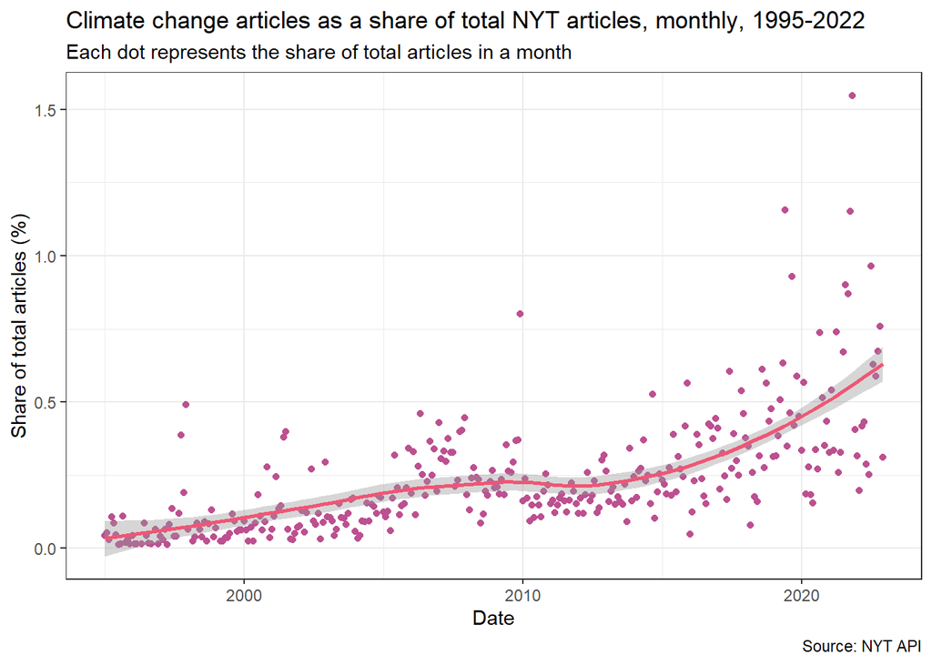

In the chart above, it’s also clear that there seems to be some kind of seasonal pattern to the publishing.

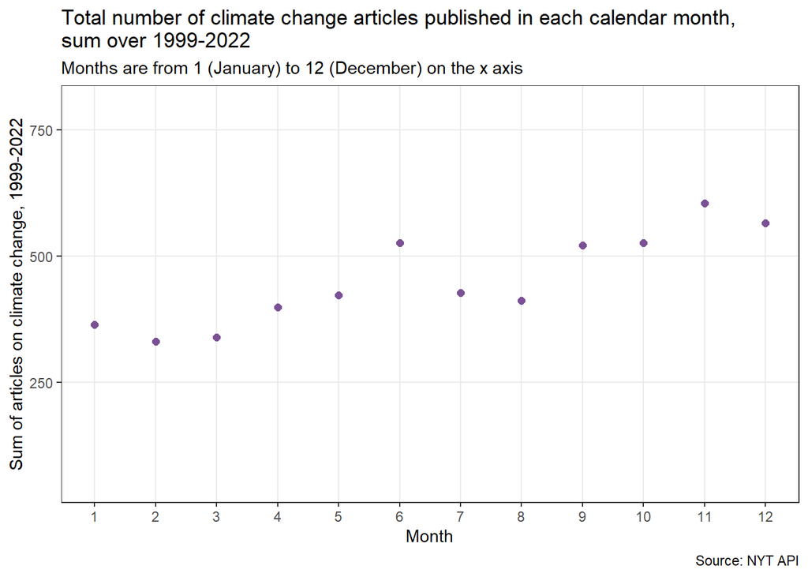

From these charts we can see that generally there tend to be more articles published toward the end of the year, and in June.

**Frequency by desk**

In the next section, we look to see how coverage has shifted between desks.

The following table highlights the variation in aggregated NYT desks (I aggregated desk codes that likely reflect historical shifts in naming (e.g. Business vs. Business Desk), and put all desks with fewer than 100 articles into their own “other” category). The National, Foreign and Editorial desks have a significant share of articles, reflecting their historic dominance and significant size. A significant number are either unclassified or in smaller desks.

```
##
##     Books  Business   Climate   Culture Editorial   Foreign   Letters    Metro.
##       111       406       449       136       571       585       107       243
##  National      None      OpEd     Other   Science
##       584       867       394       694       293
```

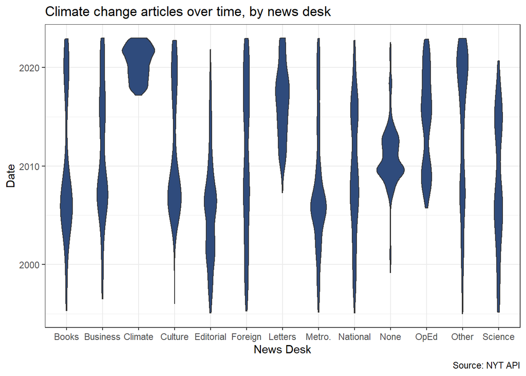

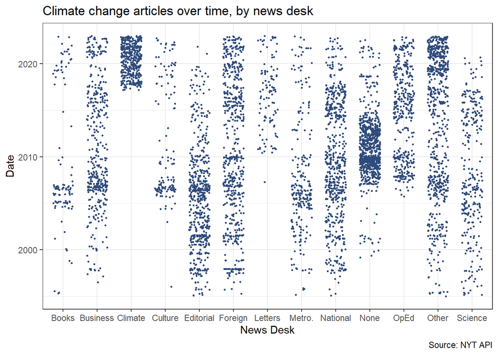

These charts provide a significant amount of information.

Some basic notes:

**Frequency by Page Number**

Next, we turn to the page numbers – which gives a sense to the relative importance accorded to climate change as a topic on any single day.

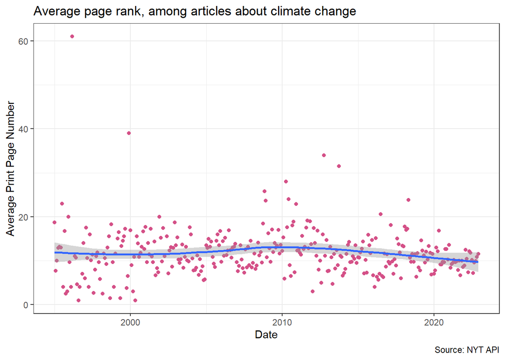

There generally seems to be a relatively constant page rank for articles about climate change – but it seems likely that earlier years are influenced by having relatively few articles. There does seem to be a downward trend “towards the front” in the past decade.

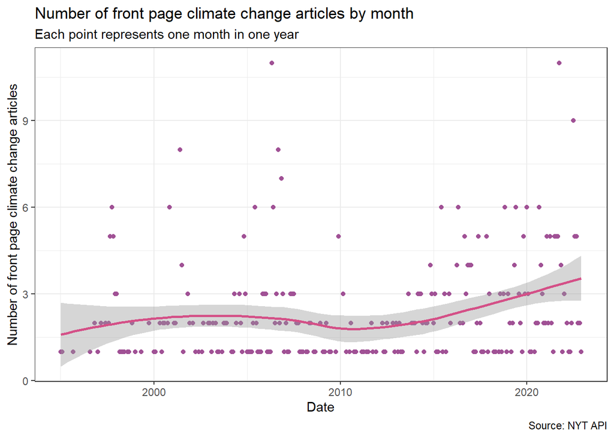

One way around the issues with the previous chart is to just focus on front page stories (aka print page 1). Indeed, over the past five years, there has been an increase in the number of more front page stories about climate change. The peaks of front page coverage were in May 2006 (an Inconvenient Truth was released on May 24) and October of 2021.

## Presidents and Scientists, Nation and World

**We’ll now use quanteda to dig a little deeper into what words are used in the abstracts.**

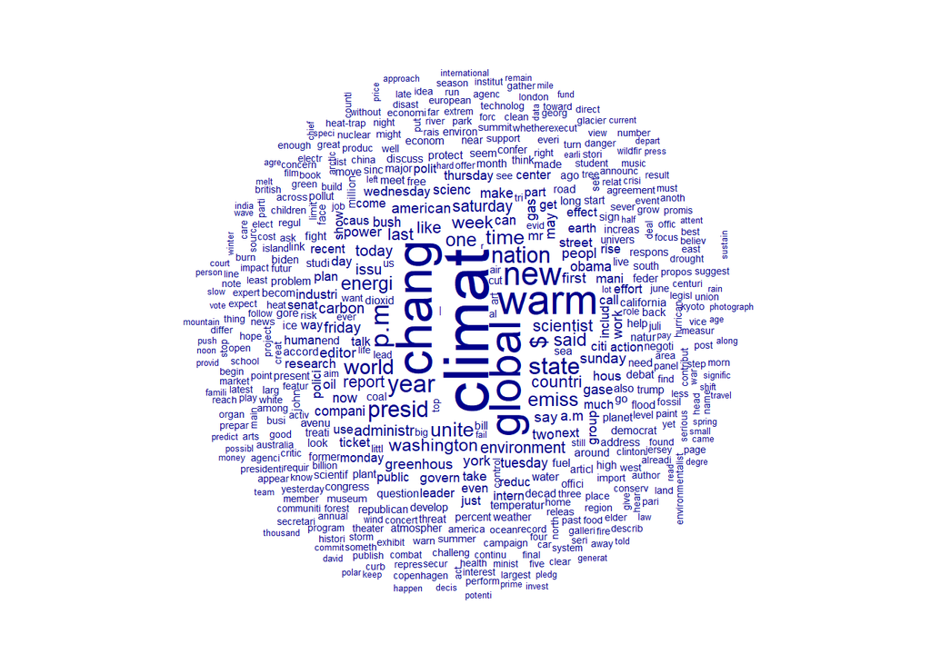

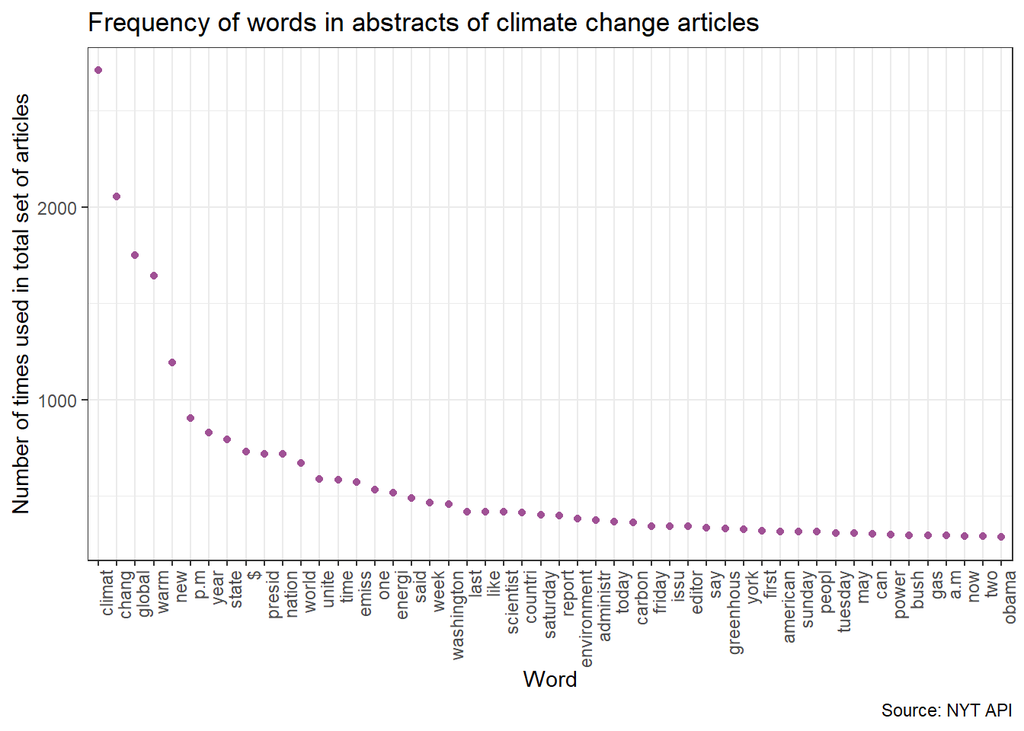

## Natural disasters

Finally, the rest of this project will be focused on looking at how natural disasters drive coverage of climate policy, using a dictionary for natural disasters to sort through our existing corpus of articles.

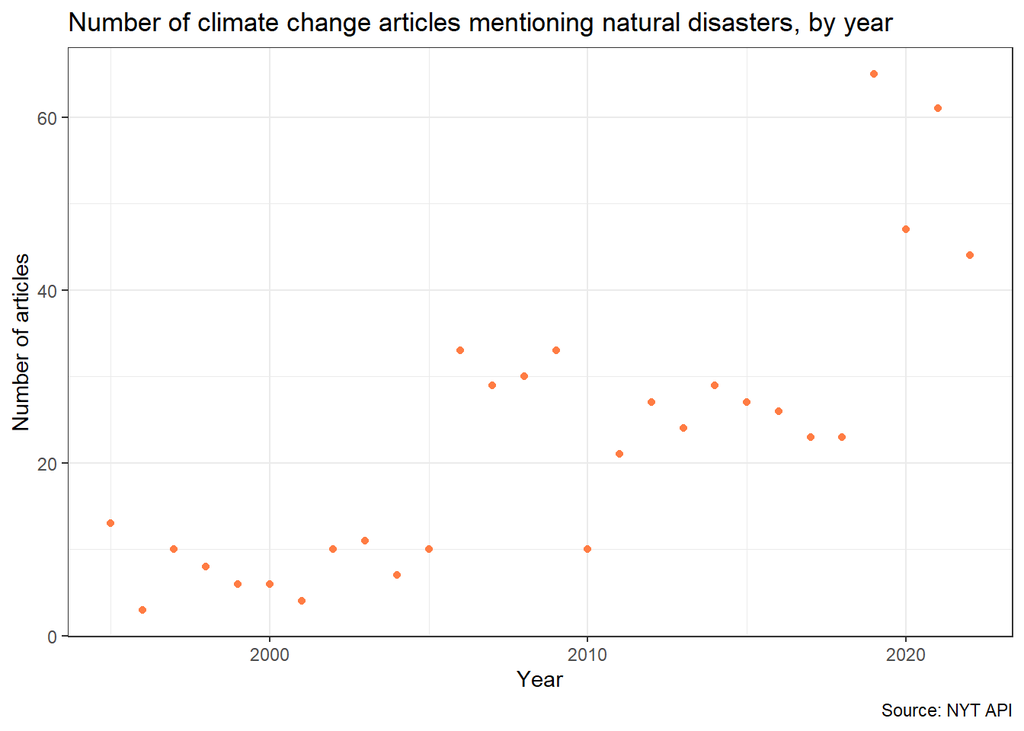

Indeed, while the number of climate change articles has been increasing generally, it is also seems like there are more articles specifically referencing natural disasters as part of the coverage.

**Natural disasters and climate change in the NYT**

NB: The climate change terms used in the initial analysis are: “climate change” “global warming” “greenhouse effect” “climate catastrophe” “climate emergency” “climate crisis” and “global heating.” In this section, I build a corpus of NYT article from 1995 to 2022 that include terms of climate change. To select these terms, I drew from some established work ([see Lineman et al](https://journals.plos.org/plosone/article?id=10.1371/journal.pone.0138996), or Kumar and Li).